# INet for Network Integration

Valeria Policastro et al.

2025-06-18

In the context of network integration, we propose the `INet` algorithm. `INet` assumes a similar network structure, representing latent variables in different network layers of the same system. Therefore, by combining individual edge weights and topological network structures, `INet` first constructs a `Consensus Network` that represents the shared information underneath the different layers to provide a global view of the entities that play a fundamental role in the phenomenon of interest. Then, it derives a `Case Specific Network` for each layer containing peculiar information of the single data type not present in all the others.

## Installation of INetTool

```r
# Install from CRAN
# install.packages("INetTool")

# Install from GitHub
# install.packages("devtools")
#devtools::install_github("ValeriaPolicastro/INet-Tool")
```

# Example

Load the package and a list with the example datasets. In this case, columns of both datasets represent patients, while rows represent gene expression, methylation and mirna expression respectively.

```r
library(INetTool)
data("exampleL_data")
```

## Constuction of the Networks

If you do not have already the weighted networks, as in our example, you can construct them throughout this function:

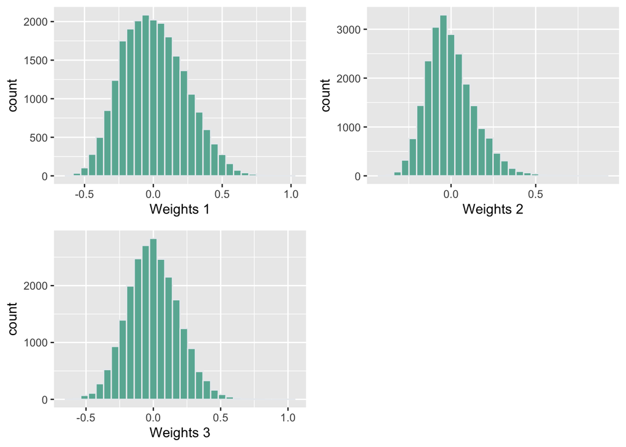

```r
net <- constructionGraph(exampleL_data)
```

*If you have already the networks skip this step.*

The function constructs similarity networks based on pearson correlation and the percentile parameter, in our example it constructs 3 patient similarity networks.

For this example we named:

**adjL** the list of weighted adjacency matrices needed for the next functions

```r
adjL <- net$Adj
```

**graphL** the list of graphs needed for the next functions

```r
graphL <- net$Graphs
```

## 1) Pre Analysis

To detect how similar are the networks you can use the Jaccard distance matrix function:

```r
JWmatrix(graphL)
```

```
##           vetI      vetI      vetI
## vetI 0.0000000 0.9046842 0.9203484
## vetI 0.9046842 0.0000000 0.9434781
## vetI 0.9203484 0.9434781 0.0000000
```

or the *Mean Weighted Jaccard Distance for Multilayer Networks* a global distance function:

```r
JWmean(graphL)
```

```
## [1] 0.9228369
```

### Networks measures

To calculate different measures on the different graphs you can easly use the following function:

```r
measures <- measuresNet(graphL, nodes.measures=F)
```

(default nodes.measures=T gives measures also about the nodes)

The measures of the first graph:

```r
measures[[1]]
```

```
## $graphsMeasures
##                         values
## vertices          2.150000e+02
## edges             1.049000e+03
## transitivity      5.180470e-01
## diameter          4.318253e+00
## modularityLouvain 6.744669e-01
## edgeDensity       4.559878e-02
## assortativity     2.122518e-01
## centrDegree       7.589654e-02
## centrBetween      1.076573e-01
```

### Plot Networks

To plot all the layers in one plot use:

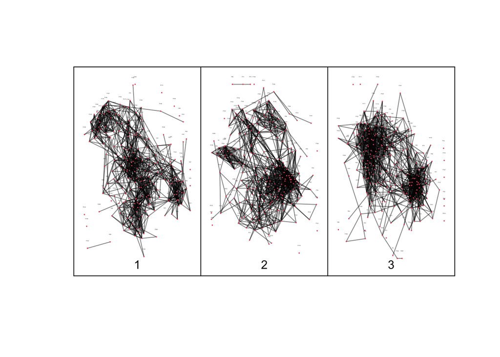

```r
plotL(graphL,vertex.cex=.1,vertex.labels.cex=.1, vertex.color = 18)
```

different parameter can be specified for the plot.

## 2) Consensus Network:

To construct the *Consensus Network* use a list of weighted adjacency matrices:

*Note: `consensusNet` needs the same row and column names for all the matrices, if you do not have it use the `adj_rename`function before the consensus*

```r
Con <- consensusNet (adjL, theta=0.05)
```

```
## Multilayer network distance: 0.3488464
## Multilayer network distance: 0.08620715
```

From our simulation study, we detected that the best theta for 500 nodes network is 0.04 and the best one for 100 nodes network is 0.06,thus for this example with 200 nodes we setted the parameter to 0.05.

The output are:

- the *Consensus Network*

```r
Con$graphConsensus
```

```
## IGRAPH 7a596f2 UNW- 215 39 --
## + attr: name (v/c), weight (e/n)
## + edges from 7a596f2 (vertex names):
##  [1] P7  --P89  P7  --P96  P10 --P21  P12 --P48  P13 --P53  P27 --P115
##  [7] P27 --P169 P34 --P45  P34 --P48  P34 --P49  P34 --P155 P36 --P96
## [13] P44 --P89  P45 --P48  P45 --P52  P45 --P55  P45 --P155 P48 --P49
## [19] P48 --P55  P48 --P71  P49 --P71  P52 --P55  P80 --P193 P88 --P173
## [25] P89 --P96  P92 --P151 P95 --P168 P102--P112 P103--P166 P112--P135
## [31] P112--P181 P117--P181 P118--P134 P135--P176 P135--P189 P138--P169
## [37] P173--P185 P176--P181 P181--P189
```

- the *Mean Weighted Jaccard Distance for Multilayer Networks*

```r
Con$Comparison
```

```
##                  [,1]
## Comparison 0.92283689
## CompPost   0.34884641
## CompPost   0.08620715
```

- the similar graphs before the thresholding

```r
Con$similarGraphs
```

```
## [[1]]
## IGRAPH 0f9698e UNW- 215 2691 --
## + attr: NA (v/c), name (v/c), weight (e/n)
## + edges from 0f9698e (vertex names):
##  [1] P1--P2   P1--P3   P1--P4   P1--P5   P1--P11  P1--P12  P1--P13  P1--P16
##  [9] P1--P17  P1--P18  P1--P19  P1--P20  P1--P21  P1--P53  P1--P78  P1--P88
## [17] P1--P171 P1--P173 P2--P3   P2--P4   P2--P6   P2--P10  P2--P11  P2--P12
## [25] P2--P13  P2--P15  P2--P17  P2--P18  P2--P19  P2--P20  P2--P21  P2--P45
## [33] P3--P4   P3--P5   P3--P8   P3--P9   P3--P12  P3--P14  P3--P16  P3--P17
## [41] P3--P18  P3--P19  P3--P20  P4--P8   P4--P10  P4--P11  P4--P15  P4--P17
## [49] P4--P18  P4--P19  P4--P21  P5--P9   P5--P12  P5--P14  P5--P16  P5--P17
## [57] P5--P18  P5--P19  P5--P20  P6--P8   P6--P9   P6--P14  P6--P17  P7--P23
## + ... omitted several edges
##
## [[2]]
## IGRAPH ef5879a UNW- 215 2691 --
## + attr: NA (v/c), name (v/c), weight (e/n)
## + edges from ef5879a (vertex names):
##  [1] P1--P10  P1--P13  P1--P19  P1--P21  P1--P29  P1--P34  P1--P35  P1--P52
##  [9] P2--P38  P3--P28  P3--P39  P3--P41  P3--P47  P3--P51  P3--P58  P3--P61
## [17] P4--P8   P4--P14  P4--P15  P4--P28  P4--P38  P4--P39  P4--P41  P4--P47
## [25] P4--P51  P4--P58  P4--P63  P5--P7   P5--P9   P5--P11  P5--P16  P5--P20
## [33] P5--P27  P5--P36  P5--P43  P5--P44  P5--P82  P5--P89  P5--P95  P5--P96
## [41] P5--P115 P5--P138 P5--P158 P5--P168 P5--P169 P6--P16  P6--P23  P6--P163
## [49] P7--P11  P7--P27  P7--P36  P7--P43  P7--P44  P7--P82  P7--P89  P7--P96
## [57] P7--P158 P8--P10  P8--P14  P8--P19  P8--P21  P8--P25  P8--P28  P8--P29
## + ... omitted several edges
##
## [[3]]
## IGRAPH f80f822 UNW- 215 2691 --
## + attr: NA (v/c), name (v/c), weight (e/n)
## + edges from f80f822 (vertex names):
##  [1] P1--P2   P1--P37  P1--P43  P1--P73  P1--P184 P1--P214 P2--P5   P2--P7
##  [9] P2--P25  P2--P43  P2--P47  P2--P59  P2--P89  P2--P112 P2--P135 P2--P142
## [17] P2--P181 P2--P189 P2--P195 P3--P20  P3--P171 P4--P124 P5--P7   P5--P11
## [25] P5--P23  P5--P27  P5--P38  P5--P44  P5--P66  P5--P89  P5--P96  P5--P102
## [33] P5--P121 P5--P132 P5--P142 P5--P148 P5--P157 P5--P158 P5--P169 P5--P181
## [41] P5--P189 P5--P211 P6--P9   P6--P47  P6--P73  P6--P112 P6--P135 P6--P140
## [49] P6--P142 P6--P184 P6--P189 P6--P199 P6--P214 P6--P215 P7--P59  P7--P89
## [57] P7--P96  P7--P102 P7--P121 P7--P132 P7--P138 P7--P142 P7--P158 P7--P163
## + ... omitted several edges
```

The similar graphs are useful if it is needed to change the final thresholding, instead of computing again the algorithm you can use directly `thresholdNet` function.

Plotting the *Consensus Network* you can find the common informations present in all the layers:

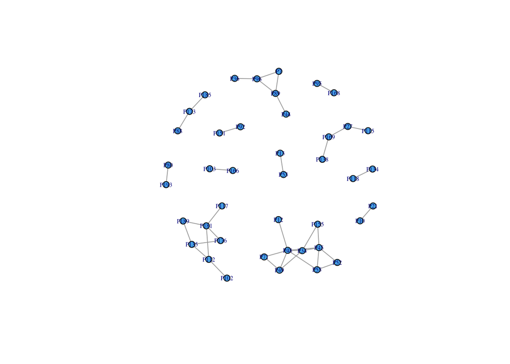

```r
plotC(Con$graphConsensus,vertex.size=6, vertex.label.cex =0.5,vertex.color = 18)
```

## 3) Case Specific Networks:

To construct *Case Specific Networks* one for each layer to give information of the peculiar layer not present in the *Consensus*:

```r
specificNet(graphL, Con$graphConsensus)
```

```
## $GraphsDifference
## $GraphsDifference[[1]]
## IGRAPH b01937e UNW- 215 1010 --
## + attr: name (v/c), weight (e/n)
## + edges from b01937e (vertex names):
##  [1] P1--P173 P1--P171 P1--P88  P1--P78  P1--P53  P1--P21  P1--P20  P1--P19
##  [9] P1--P18  P1--P17  P1--P16  P1--P13  P1--P12  P1--P11  P1--P5   P1--P4
## [17] P1--P3   P1--P2   P2--P45  P2--P21  P2--P20  P2--P19  P2--P18  P2--P17
## [25] P2--P15  P2--P13  P2--P12  P2--P11  P2--P10  P2--P6   P2--P4   P2--P3
## [33] P3--P20  P3--P19  P3--P18  P3--P17  P3--P16  P3--P14  P3--P12  P3--P9
## [41] P3--P8   P3--P5   P3--P4   P4--P21  P4--P19  P4--P18  P4--P17  P4--P15
## [49] P4--P11  P4--P10  P4--P8   P5--P20  P5--P19  P5--P18  P5--P17  P5--P16
## [57] P5--P14  P5--P12  P5--P9   P6--P17  P6--P14  P6--P9   P6--P8   P7--P189
## + ... omitted several edges
##
## $GraphsDifference[[2]]
## IGRAPH a33c2b7 UNW- 215 1014 --
## + attr: name (v/c), weight (e/n)
## + edges from a33c2b7 (vertex names):
##  [1] P1--P52  P1--P35  P1--P34  P1--P29  P1--P21  P1--P19  P1--P13  P1--P10
##  [9] P2--P38  P3--P61  P3--P58  P3--P51  P3--P47  P3--P41  P3--P39  P3--P28
## [17] P4--P63  P4--P58  P4--P51  P4--P47  P4--P41  P4--P39  P4--P38  P4--P28
## [25] P4--P15  P4--P14  P4--P8   P5--P169 P5--P168 P5--P158 P5--P138 P5--P115
## [33] P5--P96  P5--P95  P5--P89  P5--P82  P5--P44  P5--P43  P5--P36  P5--P27
## [41] P5--P20  P5--P16  P5--P11  P5--P9   P5--P7   P6--P163 P6--P23  P6--P16
## [49] P7--P158 P7--P82  P7--P44  P7--P43  P7--P36  P7--P27  P7--P11  P8--P51
## [57] P8--P47  P8--P41  P8--P39  P8--P31  P8--P29  P8--P28  P8--P25  P8--P21
## + ... omitted several edges
##
## $GraphsDifference[[3]]
## IGRAPH 8471b3b UNW- 215 1014 --
## + attr: name (v/c), weight (e/n)
## + edges from 8471b3b (vertex names):
##  [1] P1--P214 P1--P184 P1--P73  P1--P43  P1--P37  P1--P2   P2--P195 P2--P189
##  [9] P2--P181 P2--P142 P2--P135 P2--P112 P2--P89  P2--P59  P2--P47  P2--P43
## [17] P2--P25  P2--P7   P2--P5   P3--P171 P3--P20  P4--P124 P5--P211 P5--P189
## [25] P5--P181 P5--P169 P5--P158 P5--P157 P5--P148 P5--P142 P5--P132 P5--P121
## [33] P5--P102 P5--P96  P5--P89  P5--P66  P5--P44  P5--P38  P5--P27  P5--P23
## [41] P5--P11  P5--P7   P6--P215 P6--P214 P6--P199 P6--P189 P6--P184 P6--P142
## [49] P6--P140 P6--P135 P6--P112 P6--P73  P6--P47  P6--P9   P7--P211 P7--P195
## [57] P7--P189 P7--P181 P7--P163 P7--P158 P7--P142 P7--P138 P7--P132 P7--P121
## + ... omitted several edges
##
##
## $percentageOfSpecificity
## [1] 0.9628217 0.9666349 0.9666349
```

## 4) INet Plot

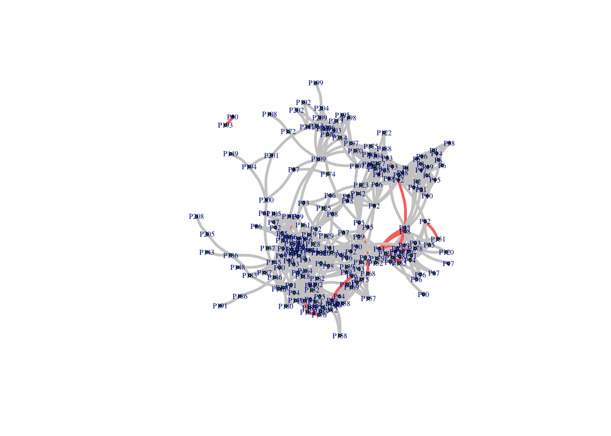

```r
plotINet(adjL[[1]], Con$graphConsensus, vertex.labels.cex=.01, vertex.size=2)
```